# Age and Unemployment Rates

Contributors:

CHIU, CHEUK MAN (github.com ID: cheukman1207 )

BOYCE, HAYLEY (github.com ID: hfboyce )

## Overview:

To conduct our analysis, we want to know if an individual’s age has a significant effect on getting employed. In order to expand on that question, in this project, for a set of developed countries, we will be determining if the mean unemployment rate changes based on age group. The exploratory question that we will attempt to answer in this analysis is

*" For developed countries in the past 5 years, is there a difference in the mean unemployment rates in different age groups?"*.

The different age groups we will be comparing are 15-24, 25-54, 55-64. A large assumption we are making is that both observations of males and female are equally important. To help visualize our data, we created a violin plot with overlaying jitter in the hopes of giving a better idea on the distributions of data for each age group. To explore more closely, the 95% confidence intervals of the average unemployment rates for each age group give a better understanding of the differentiation of the means unemployment rates. To answer this question we will use ANOVA to see if the selected age groups differ. Depending on the results of the ANOVA, further analysis using pairwise t-tests will be conducted to explore exactly which age groups differ from one another.

## Data:

Dataset: [Employment: Unemployment rate by sex and age group](https://stats.oecd.org/index.aspx?queryid=54743) by OECD.org.  
Also can be found in the data directory of this repository. From this data we are using the following information.

- Variables/factors for data wrangling:

| Variable Name | Description | Type |
| --- | --- | --- |
| Years | 2012-2016 | Discrete |
| Countries | A list of 34 countries | Categorical |

| List of selected countries: |  |  |  |  |  |  |
| --- | --- | --- | --- | --- | --- | --- |
|  | Australia | Austria | Belgium | Canada | Chile | Czech Republic |
|  | Denmark | Estonia | Finland | France | Germany | Greece |
|  | Hungary | Iceland | Ireland | Israel | Italy | Japan |
|  | Korea | Latvia | Lithuania | Luxembourg | Netherlands | New Zealand |
|  | Norway | Poland | Portugal | Slovak Republic | Slovenia | Spain |
|  | Sweden | Switzerland | United Kingdom | United States |  |  |

- Variables/factors for analysis:

| Variable Name | Description | Type |
| --- | --- | --- |
| Value | Unemployment Rates | Numeric |
| Age.Group | 15-24, 25-54 or 55-64 | Categorical |

## Usage:

To reproduce our analysis please do the following:

1. Clone this repo, and locate yourself to the root of where this project is saved.
2. You may choose to use the run_all.sh script in your bash with:

```
bash run_all.sh
```

Or use the Makefile with the following command to make all the files needed for the analysis and creates the report:

```
make all
```

To delete all the files created from the scripts you can use the command:

```
make clean
```

The run_all.sh and Makefile consist of the the following commands:

```
#1 Import data and perform data wrangling
Rscript src/01_clean-data.R data/unemployment-age-gender.csv data/unemployment-age-gender-countries-filtered-clean.csv

#2  Create explanatory visualization
Rscript src/02_visualize-data.R data/unemployment-age-gender-countries-filtered-clean.csv img/

#3  Perform ANOVA
Rscript src/03_anova.R  data/unemployment-age-gender-countries-filtered-clean.csv results/anova-table.csv

#4  Perform pairwise T-tests
Rscript src/04_pairwise-ttest.R  data/unemployment-age-gender-countries-filtered-clean.csv results/pairwise-test-table.csv

#5  Creates the final report
Rscript -e "rmarkdown::render('doc/age-and-unemployment-rates-report.Rmd')"
```

## Procedure:

The procedure for generating the final report and all the associated files is shown below. For reference a flowchart has been included:

Script 1- 01_clean-data.R:

- **Inputs**: unemployment-age-gender.csv
- **Purpose**: This script takes the raw data and will clean and filter it.
- **Outputs**: unemployment-age-gender-countries-filtered-clean.csv

Script 2 - 02_visualize-data.R:

- **Inputs**: unemployment-age-gender-countries-filtered-clean.csv
- **Purpose**: This script creates exploratory visualizations for target audiences.
- **Outputs**: histrogram.png, violin.png, mean-CI.png

Script 3 - 03_anova.R:

- **Inputs**: unemployment-age-gender-countries-filtered-clean.csv
- **Purpose**: This script takes the performs ANOVA tests on the `Age.Group` values.
- **Outputs**: anova-table.csv

Script 4 - 04_pairwise-ttest.R:

- **Inputs**: unemployment-age-gender-countries-filtered-clean.csv
- **Purpose**: This script creates a pairwise t-test table with conclusions explaining if we reject or fail to reject the null hypothesis.
- **Outputs**: confidence-interval-estimate-table.csv, pairwise-test-table.csv

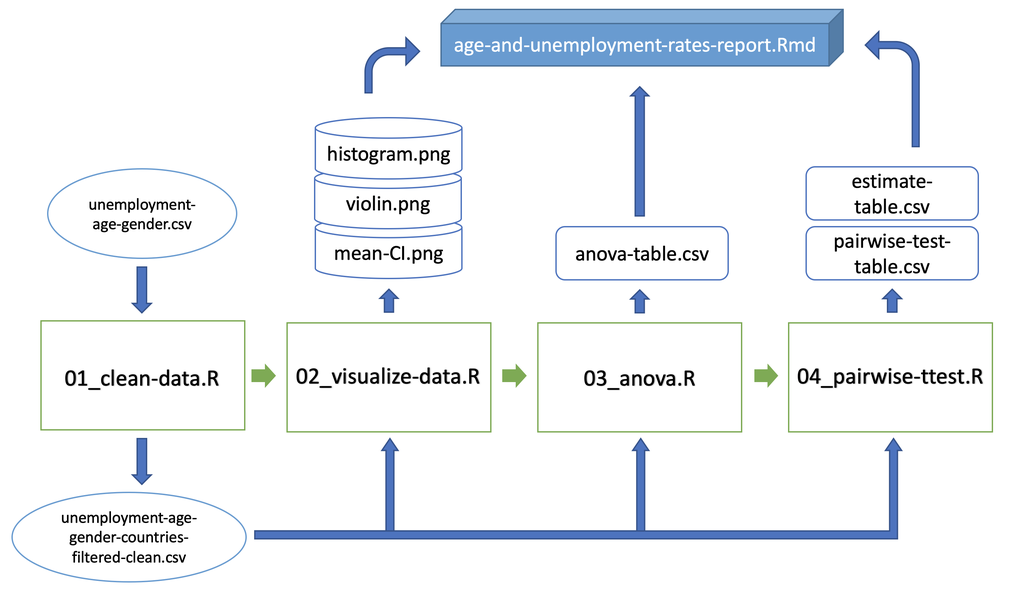

## Dependencies:

R & R libraries: (version 3.5.1 )

- tidyverse
- ggplot2
- broom
- [dplyr](https://github.com/tidyverse/dpylr)

## Report:

The report the Analysis can be found here: /doc/age-and-unemployment-rates-report.md

## Releases:

- v0.1
- V2.0
- V3.0